# oDCM - Opening Lecture

Hannes Datta

[output not shown]

[output not shown]

### Welcome to oDCM!

We're about to start with the first lecture of this class.

If you haven't done so, please

- **explore the course page** at https://odcm.hannesdatta.com.

### Agenda

- Part 1 (14.45 to about 15.45)
  - Getting to know each other
  - Motivation for the course
  - Course framework and learning goals
  - Agenda and practical arrangements
- Break
- Part 2: Python Bootcamp on your laptops (about 16.00 - 17.30)

### Disclaimer

- This is not a class that merely teaches you Python (but, if you invest time, you'll learn Python on the way!)
- You can also extract web data using other software packages (e.g., R)
- Mix of students at various levels (e.g., beginners, advanced Python users)
- Course mostly takes place on campus (based on student feedback); attendance is not mandatory but strongly encouraged
- I will not record any online or offline sessions; slides will be posted always
- Consider me your coach, not your *distant professor*
- Slow me down if you need to

### About myself

- scraping nerd — started in 2008 using Visual Basic in Excel
- started doing my own research with scraped and API-extracted data in 2012 (so, 10+ years experience)
- left Germany around your age, now many years in NL
- Associate Professor at Tilburg University

### Key areas of expertise

- Substantive interests
  - streaming business models (e.g., music, movies)
  - marketing-mix modeling and optimization
- Methodological interests
  - online data collection via APIs and web scraping
  - causal effects with observational data

### Teaching activities (all openly available)

- MSc Marketing Analytics
  - Data preparation and workflow management (https://dprep.hannesdatta.com)
  - Online data collection and management (https://odcm.hannesdatta.com)
  - MSc Thesis supervision (https://thesis.hannesdatta.com)
- Other initiatives
  - Tilburg Science Hub (https://tilburgsciencehub.com)
  - Music-to-scrape.org (https://music-to-scrape.org)
  - YouTube channel (https://youtube.com/c/hannesdatta)
  - My code (https://github.com/hannesdatta)
  - More about my work (https://hannesdatta.com)

### Getting to know you

- What's your background - previous education (e.g., program)?
- Any experience in Python (or other programming languages)?
- What are your passions & talents? (+ why I am asking you this…)

### Motivation for course

- started out as a PhD student without data
- was interested in music, and found website with data (https://last.fm)
- no best practices in scraping; learnt all by myself and made many mistakes
- scraping undervalued in academic job market, **but**, key role in shaping relevance and rigor of your work
- now scraping and APIs are a large part of what defines me…

### Selection of scraping projects I've undertaken

- investigate music streaming ([How did music consumption change with Spotify?](https://tiu.nu/spotify))
- [monitored Spotify's user interface and make lists of new releases](https://github.com/hannesdatta/data-spotify-promotions-releases)
- investigate [playlist ecosystem](https://github.com/hannesdatta/data-spotify-playlist-ecosystem) with APIs
- [scraped reviews at Amazon.com](https://journals.sagepub.com/doi/abs/10.1509/jm.11.0560)
- investigating “video streaming wars” (e.g., Netflix versus Disney+, when do consumers use multiple streaming services?), see trakt.tv
- share code [on GitHub](https://github.com/hannesdatta)
- developed a [methodological framework on scraping/APIs](https://doi.org/10.1177%2F00222429221100750) (which we use in this class)
- Faced legal battles…

### What is scraping, and what are APIs?

*With web scraping, you can capture anything you can view in a web browser*

- pricing data at bol.com
- reviews at [Amazon.com](https://amazon.com)
- movie data at imdb.com or reviews at Rotten Tomatoes

*With APIs, you obtain official data from a firm in a programmatic way*

- e.g., as a developer, interact with Facebook, Instagram, Twitter
- as a researcher, construct data set from analytics firms

### Quick web scraper in Python (I)

- Let's first import some packages

```python
import requests
```

- And then call a particular URL (check it out in your browser!)

```python
url = 'https://music-to-scrape.org/artist?artist-id=AR19SOA1187B98F6E6'
webrequest = requests.get(url)
```

### Quick web scraper in Python (II)

- Finally, let's retrieve the artist name (we use HTML classes for this)

```python
from bs4 import BeautifulSoup
soup = BeautifulSoup(webrequest.text)
print(soup.find(class_='artist_info_title').text)
```

```
Bob Neuwirth
```

- Works with any website, even anything you see in a browser (e.g., apps)

### Quick APIs in Python

- APIs are official interfaces by firms for programmers to extract or submit data, or obtain access to an algorithm
- They work *like* websites (i.e., you can call them with the same snippets as before), but usually you need to pay or at least sign up for the service

```python
# let's get some data from the API of music-to-scrape
api_request = requests.get('https://api.music-to-scrape.org/artist/info/?artist=Bob Neuwirth')
```

- let's structure the output in the JSON format

```python
api_request.json().get('total_plays')
```

```
526
```

### Opportunities with web data

- discover/document novel phenomena (e.g., new platforms/technologies)
- boost relevance for managers (e.g., integrate novel data from ChatGPT)
- improving methods (e.g., get data to try out new methods, such as review data & text analysis, images, videos)
- improved inferences (i.e., get more accurate results)

### Getting inspired...

- *What are cool websites/services you're using often?!*
- *What are important societal issues right now that directly or indirectly affect your lives?*
- *As a marketer, how could you use the API of OpenAI to automate/invent something new?*

Let's talk about it right now…

### Why to care (as a marketer...) (I)

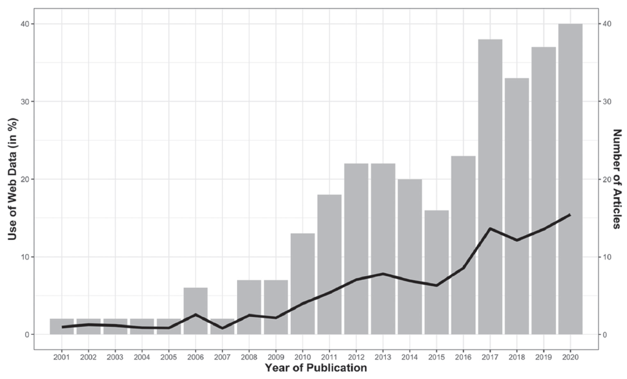

### Why to care (as a marketer...) (II)

[figure not shown]

### Web data versus other marketing data (I)

*Why do we need a course on this? Isn't this how research is always done?*

**Yes, but collecting *web data* is different from other datasets!**

- data source selection
  - finding the *right* data source may be difficult as **many** potential alternatives exist
  - differ in delivery formats (website versus API, compared to CSV/databases)
  - access to data that is *not* available commercially (or that a firm would not like to share)

### Web data versus other marketing data (II)

- extraction design
  - which information to select (which is available?!)
  - type of variables (sales is rare; review scores are abundant)
  - different stakeholders that could potentially be addressed
  - need to tackle legal and ethical issues

### Web data versus other marketing data (III)

- collecting data at scale!
  - unprecedent: it's totally automatic (but prone to errors)
  - need to put *monitoring* procedures in place
  - data is not documented, and there is no direct way to ask questions about the data (sampling?! generalizability?)

Each project is totally unique - that's why there is no universal “best way” to approach things…

### Methodological Framework

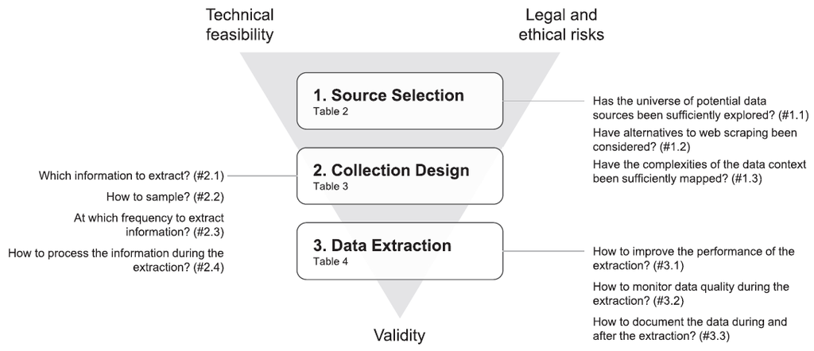

### Learning Goals of this course

- **Explain** how to use web data for **creating marketing insight**
- **Select web data sources** and evaluate their value to inform a specific research context or business problem
- **Design the web data collection** while balancing validity, technical feasibility, and exposure to legal/ethical risks
- **Collect data** via web scraping and Application Programming Interfaces (APIs) by mixing, extending, and repurposing code snippets
- **Document and archive collected data** and make it available for public (re)use

### Positioning in the study program

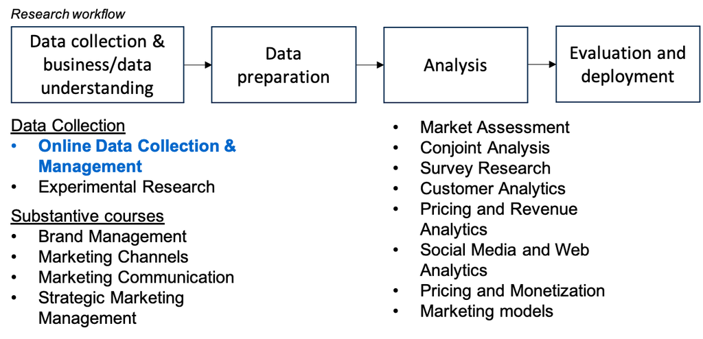

### Course structure and grading

- Weekly modules, structured along the methodological framework
  - On-campus lectures and tutorials
  - Self-study
  - On-campus (sometimes online) coaching sessions
- Project in which you put into practice your skills (50% of your grade)
- Online computer exam (50% of your grade)
- Bonus points available (max .5 on final course grade)

### This year's team project: AI tools and platforms (I)

- We're currently experiencing many new AI-based products/services that are invented/launched.
- You know way more than I do… so… let's hear some!

**Goals:**

In the context of **AI-based tools and platforms**,

- understand and present “data universe”
- select one or multiple data source(s) and collect the data (scraping, APIs)
- document the data for public (re)use

### This year's team project: AI tools and platforms (II)

**Find your sweet spot!**

- for websites, this is likely going to be an aggregator (e.g., prompt marketplaces)
- for APIs, this is likely some link between a dataset that you have AND the API of OpenAI
- brainstorm about it…

### This year's team project: AI tools and platforms (III)

- Specifics
  - scrape data via web sites or APIs
  - work through the entire method framework
  - receive feedback by students and me (your coach)
  - inspiration for the setup: [past projects](https://odcm.hannesdatta.com/docs/project/resources/pastprojects/)
  - legacy [project ideas](https://odcm.hannesdatta.com/docs/project/resources/projectideas/)
- Evaluation
  - [grading rubric available](https://odcm.hannesdatta.com/docs/project/grading/)
  - self- and peer assessment used

### Course website

Visit https://odcm.hannesdatta.com!

- It's open education, **so spread the word!**
- Course website is your #1 resource, Canvas only used for
  - posting important announcements,
  - sign up for teams, and
  - submitting data challenges/projects.
- Do all students have access to Canvas?

### Common struggles & tips

- Take time to become acquainted with the course (e.g., not using Canvas)
- Can be tough at first, but you will gain experience rapidly!
- It can be overwhelming to follow dPrep and oDCM simultaneously, but the skills you learn are important for your course work, Master Thesis & future career!
- Easing your start-up pain
  - Start preparing early on (the first weeks will be the most challenging!)
  - Have the same group members across dPrep and oDCM
  - Collaborate with each other and try to help one another, also across teams!
  - Be in touch via WhatsApp for Business (add +31 13 466 8938)

### My commitment

- Get up to speed with both web scraping and APIs (and know when to pick which one!)
- Learn a bit of Python, **but**, becoming an expert requires years of practice
- Discuss own work and ideas, **but** requires interaction, talking to me, working hard
- Open software (usable right away, no admin rights required)
- Bring in your own ideas, don't be afraid to study topics off the main stream!
- I value diversity! Be who you want to be. Say what you want to say.

### Brain-dead by coding

- Coding can be extremely frustrating if you're starting out
- I tend to become semi-“brain-dead” after a day of coding
- Take breaks! Stop coding. Go for a run. Start again.
- You will learn from your mistakes
- Use cheat sheets and our support section

→ quick feedback loops in first few weeks

### Steps of escalation & getting in touch

When you run into trouble, this is your way out!

1. Try to find the info on the course website or Pulse
2. Ask Chat GPT / Google / Stackoverflow
3. Ask friend/classmate (form learning groups)
4. Can it wait? Defer to lecturer or feedback sessions.
5. If it can't wait: be in touch with me (–> next slide!)

### Use of WhatsApp

- Please use WhatsApp: +31 13 466 8938.

[figure not shown]

- Being in touch via email is typically slower

### What's in for you?

- Investment in research skills
  - e.g., collect own data & shape its creation to create relevant and rigorous research
- Essential skills for entrepreneurs
  - e.g., have your own company on the basis of web data and APIs
  - be the linking pin (interface between marketing and analytics)
- Showcast expertise in coding

### Success factors

Please tell me **what would make this course a success** for you

### Next steps

- We will continue with our Python bootcamp after a break
- Haven't followed the installation guide? Check it out on the course page now! (tutorials -> software installation)

**Any questions so far?!**